# EBAME4 tutorial

October 06, 2018

In this tutorial we are going to explore the unannotated ORFs that we have been able to assign to any of our categories. Let’s load some libraries:

```r
library(tidyverse)
library(ggpubr)
```

and data:

```r
load(url("http://ebame4.metagenomics.eu/data/ebame4_r-tutorial.Rda"), verbose = TRUE)
```

```
## Loading objects:
##   tara_cdata
##   hmp_cdata
##   cluster_data
##   cluster_taxonomy
```

We loaded 4 different objects:

- **cluster_data**: contains the name of the cluster, the sample where the cluster has been found, the coverage-based abundances, proportion in a sample, the category, component id and super component id.
- **cluster_taxonomy**: contains the assigned taxonomy for each of the members in a cluster. We used the [**2blca**](https://dx.doi.org/10.1038%2Fismej.2013.59) as implemented in [**MMseqs2**](https://github.com/soedinglab/mmseqs2/wiki#taxonomy-assignment-using-mmseqs-taxonomy).
- **tara_cdata**: Contains the contextual data associated to the [**TARA OCEANS**](http://ocean-microbiome.embl.de) metagenomes
- **hmp_cdata**: Contains the contextual data associated to the [**HMP1**](https://hmpdacc.org/) metagenomes

## What are the taxonomies associated to the clusters we have a hit?

We will explore the taxonomic assignations of the clusters that had a hit to the ORFs that were not annotated by MGnify. Having a taxonomic target can help us to find potential genomes where these ORFs have homologs and we might learn something from the genomic neighborhood or import some of them to anvi’o and run the pangenomics pipeline.

First we will join the tables with the cluster information and the table with the associated taxonomy at the **Kingdom** rank:

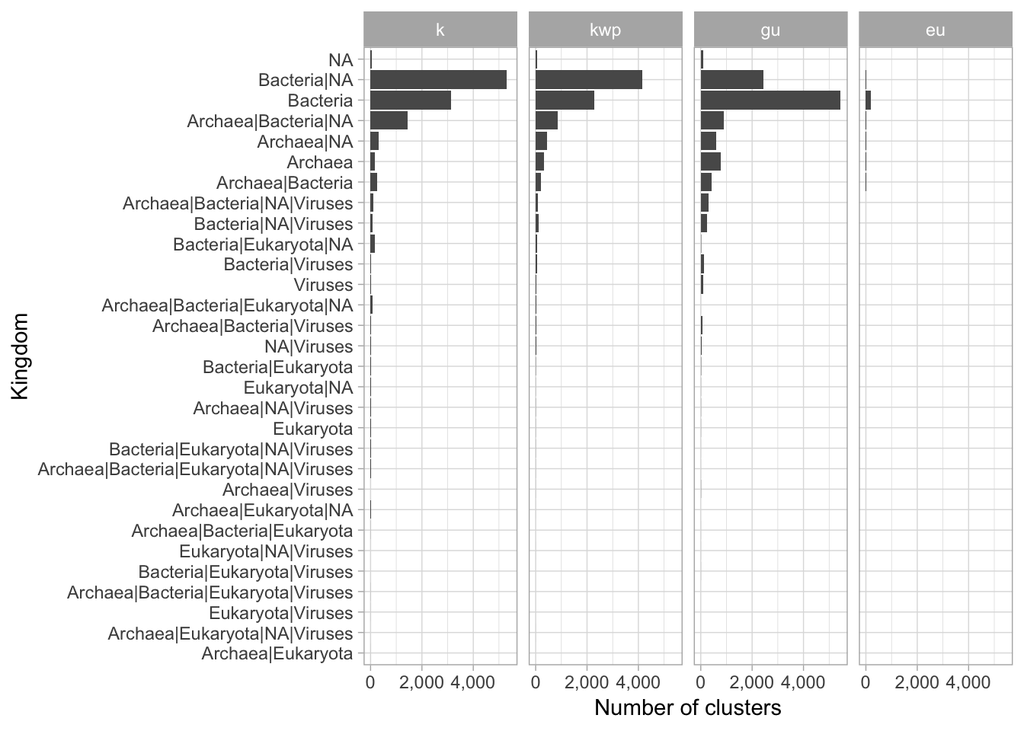

```r
cluster_taxonomy %>%
  group_by(kingdom, category) %>% # we group by the taxonomic rank and the cluster category
  count() %>% # we count how many of the groups
  ungroup() %>%
  mutate(kingdom = fct_reorder(kingdom, n, .fun = "sum"), # we order the taxonomy based on the number of clusters
         category = fct_relevel(category, c("k", "kwp", "gu", "eu"))) %>% # order the categories for visualization
  ggplot(aes(kingdom, n)) +
  geom_col() +
  facet_wrap(~category, nrow = 1) +
  theme_light() +
  rotate() +
  scale_y_continuous(labels = scales::comma) +
  ylab("Number of clusters") +
  xlab("Kingdom")
```

Don’t you see anything strange in those results?

**Answer**

**How can be possible that some EUs have a taxonomic annotation?**

```r
cluster_taxonomy %>% filter(category == "eu")
```

```
## # A tibble: 211 x 9
##    category cluster  kingdom  phylum  class  order family genus specie
##    <chr>    <chr>    <chr>    <chr>   <chr>  <chr> <chr>  <chr> <chr>
##  1 eu       10061584 Bacteria Candid… <NA>   <NA>  <NA>   <NA>  Candidatu…
##  2 eu       10202854 Bacteria Proteo… <NA>   Delt… <NA>   <NA>  Deltaprot…
##  3 eu       10283195 Bacteria Bacter… Flavo… Flav… <NA>   <NA>  Flavobact…
##  4 eu       10489724 Bacteria Proteo… <NA>   Delt… <NA>   <NA>  Deltaprot…
##  5 eu       10532694 Bacteria Proteo… <NA>   Gamm… <NA>   <NA>  Gammaprot…
##  6 eu       10538300 Bacteria Proteo… <NA>   Delt… <NA>   <NA>  Deltaprot…
##  7 eu       10606625 Bacteria Proteo… <NA>   Delt… <NA>   <NA>  Deltaprot…
##  8 eu       10640369 Bacteria Bacter… <NA>   <NA>  <NA>   <NA>  Bacteroid…
##  9 eu       10736179 Bacteria Proteo… <NA>   Gamm… <NA>   <NA>  Gammaprot…
## 10 eu       10746716 Archaea… <NA>    <NA>   <NA>  <NA>   <NA>  Candidatu…
## # ... with 201 more rows
```

Let’s have a look at one of them:

> >10061584;eu;eu_c_114901;eu_sc_79669 MQHMKRPLYRRSLKKLQNILSEVLRSSGNGGQIEFENALRRAIRHIQIIKRSAPRFGEDG DSAMVEAYEIYDRLQRLSDYPQYFSDNTRKYPDRVVSDRSNLYTNARPAAIRWDAAAMMA VPMGGEDILRNWWRPPPRPAPVKHFTQEEIEREYPAFTVRKKRSDDAGRD

Check the information of the hit: https://www.uniprot.org/uniprot/A0A2E4DZM5

Let’s go to ENA from it comes from: https://www.ebi.ac.uk/ena/data/view/PAWC01000000

Cool, it comes from an isolate… or not… Check the publication…

## Where are our hits found?

Now we will check in what temperature range are our hits found in the TARA dataset:

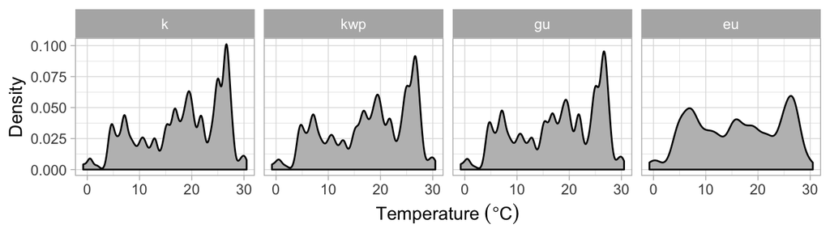

```r
cluster_data %>%
  inner_join(tara_cdata) %>%
  mutate(category = fct_relevel(category, c("k", "kwp", "gu", "eu"))) %>% # order the categories for visualization
  ggplot(aes(temperature)) +
  geom_density(fill = "grey") +
  facet_wrap(~category, nrow = 1) +
  theme_light() +
  ylab("Density") +
  xlab(expression("Temperature " ( degree*C)))
```

Where is the peak of the distribution of the hits? What is the temperature of the **Anemone hydrothermal vent**?

Publication [[**link**](https://onlinelibrary.wiley.com/doi/abs/10.1111/1462-2920.14011)]